## Class - CSE 8392 Special Topics (Advanced Application Programming)

## Quest 3 - Beautiful Soup, Regex, CSV, Tiing, PyPlot

## SMU ID – 47505527

# Part A. Beautiful Soup

Use Beautiful Soup to scrape the web page at: https://www.nasdaq.com/quotes/stock-quotes.aspx This page shows the most active stocks for the day. Wait until the end of a day (any day) and scrape the page for the date, the most active stocks, their volume and percent change in value

```python
import bs4
from bs4 import BeautifulSoup
import requests
#the requests module may need to be imported into your python
#other options include urllib or urllib3 but requests is the python preferred due to it's many features
```

```python
#requests let us to requests.get or reqeusts.post and can accept a second dict parm of key-value pairs
#we get back a response OBJECT
response = requests.get("https://www.nasdaq.com/quotes/stock-quotes.aspx")

#the text is available as resonse.content
soup = BeautifulSoup(response.content, "html.parser")

#select the table we are looking for - it includes all the children we want
tableNode = soup.find('div', {'class':'genTable marginL15px'})

# all rows are in the tBody tag, so we extract all the tbody from the table
tBodyNodes  = tableNode.find_all('tbody')

#show the number of rows we have on the table, since all rows are in the <tbody> tag
print ("lenght of rows = {}".format( len(tBodyNodes)) )
```

```
lenght of rows = 5
```

Now, after we have the rows, we'll try to extract the following

1. companyName
2. Volume of change
3. percentage of change

```python
import re

nameList = []
volumeList = []
percentageList = []

for row in tBodyNodes :
    name = row.find("div", {"class": "coName small"}).text
    nameList.append(name)

    volume = row.find_all('td')[3].text
    volumeNumbers = re.split('[^0-9]', volume)
    volumeList.append(''.join(volumeNumbers))


    changeAndNetPercentColumn = row.find("span").text
    datas = changeAndNetPercentColumn.split('\xa0')
    if(datas[1]=="▼") :
        datas[2] = "-"+datas[2]

    percentageList.append(datas[2].strip('% '))

volumeList  = [int(x) for x in volumeList]
percentageList  = [float(x) for x in percentageList]

print("Name\n",nameList)
print("Volume\n",volumeList)
print("Percentage\n",percentageList)
```

```
Name
 ['Micron Technology, Inc.', 'Invesco QQQ Trust, Series 1', 'Apple Inc.', 'Marvell Technology Group Ltd.', 'JD.com, Inc.']
Volume
 [45632121, 40453097, 35791794, 35454503, 24782813]
Percentage
 [0.47, -0.39, -0.81, -0.05, -1.1]
```

as we can see above, the data has been successfully extracted and added in their respective lists

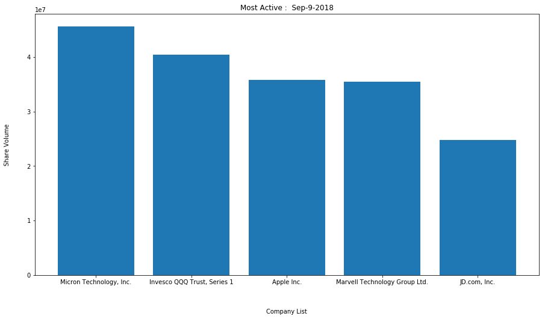

```python
#We are good to go to plot land
import matplotlib.pyplot as plt
import numpy as np
import datetime

%matplotlib inline

now = datetime.datetime.now()

plt.rcParams["figure.figsize"] = [15,8]

plt.bar(range(len(nameList)), volumeList)

plt.title("Most Active :  {}-{}-{}".format(now.strftime("%b"), now.day, now.year))

plt.xlabel("\n\n\nCompany List")
plt.ylabel("Share Volume\n\n")
plt.xticks(range(len(nameList)), nameList)

plt.show()
```

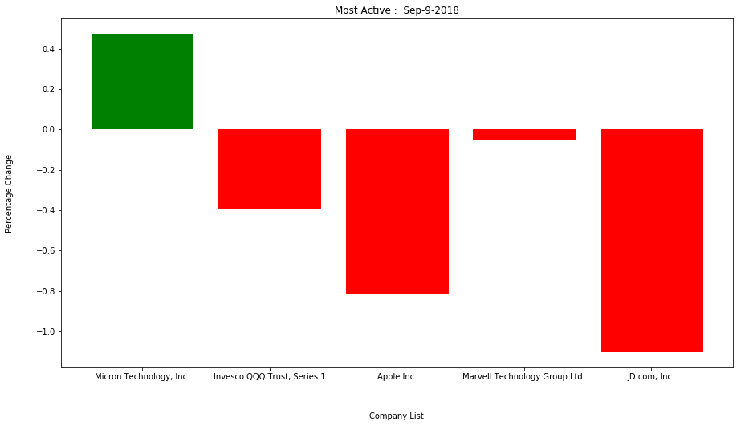

```python
plt.ylabel("Percentage Change\n\n")
plt.title("Most Active :  {}-{}-{}".format(now.strftime("%b"), now.day, now.year))
plt.xlabel("\n\n\nCompany List")

bars = plt.bar(range(len(nameList)), percentageList,color="Green")
for i in range(len(bars)) :
    if(percentageList[i]<0) :
        bars[i].set_color("RED")

plt.xticks(range(len(nameList)), nameList)
plt.show()
```

# Part B. Timing Comparison

In Quest1 you were asked to write the following code without using the Counter class. def wordsInStringToDictWordCount(s):

> """ return a dict of words in string and count  
> === wordsInStringToDictWordCount('foo bar bar') -> {'foo':1, 'bar':2}  
> === wordsInStringToDictWordCount('') -> {}  
> constraint: MAY NOT USE: Counter  
> """  
> return {"foo": 2, "bar": 1}
1. Your task is to compare the performance of your code vs. an implementation that uses the Counter class and use pyPlot to display the results.
2. Use timeit.timeit to compute the time for the two functions.
3. Create a string that contains 100,000 words. You may extract from a web page or create the string using a random number generator.  
   Plot your timing results using a PyPlot bar graph.

So, for this we have creating a dummy string of 1,20,120 words below, from https://www.lipsum.com/